# survival lecture 6

Steve Simon

May 20, 2018

Lecture 6. Time varying covariates in a Cox model. Time varying covariates allow you to account for non-proportional hazards and can model settings where patients switch from one therapy to another. You will code data for time-varying covariates, fit time-varying models, and interpret the results.

This file does not need any special libraries other than the ones listed below. Many of the data sets in this program use data from Hosmer, Lemeshow, and May. I made one minor change, however, which was to force all the variable names to lower case.

```r
library(broom)
library(dplyr)
```

```r
library(ggplot2)
library(magrittr)
library(survival)
library(tidyr)
```

## The Kaplan-Meier plot and proportional hazards.

```r
fn <- "../bin/whas500.RData"
load(fn)
fn <- "../data/heroin.txt"
heroin_rawdata <- read.delim(file=fn, sep="\t")
head(heroin_rawdata)
```

```
##   ID Clinic Status Time Prison. Dose ID.1 Clinic.1 Status.1 Time.1 Prison..1
## 1  1      1      1  428       0   50  132        2        0    633         0
## 2  2      1      1  275       1   55  133        2        1    661         0
## 3  3      1      1  262       0   55  134        2        1    232         1
## 4  4      1      1  183       0   30  135        2        1     13         1
## 5  5      1      1  259       1   65  137        2        0    563         0
## 6  6      1      1  714       0   55  138        2        0    969         0
##   Dose.1
## 1     70
## 2     40
## 3     70
## 4     60
## 5     70
## 6     80
```

```r
heroin_pt1 <- heroin_rawdata[ , 1:6]
heroin_pt2 <- heroin_rawdata[ , 7:12]
vnames <- c("id", "clinic", "status", "time", "prison_record", "dose")
names(heroin_pt1) <- vnames
names(heroin_pt2) <- vnames
heroin <- bind_rows(heroin_pt1, heroin_pt2)
heroin$dose_group <-
  (heroin$dose <=  40) +
  (heroin$dose <=  50) +
  (heroin$dose <=  60) +
  (heroin$dose <=  70) +
  (heroin$dose <= 110)
table(heroin$dose, heroin$dose_group)
```

```
##
##        1  2  3  4  5
##   20   0  0  0  0  1
##   30   0  0  0  0  2
##   35   0  0  0  0  2
##   40   0  0  0  0 30
##   45   0  0  0 10  0
##   50   0  0  0 27  0
##   55   0  0 21  0  0
##   60   0  0 52  0  0
##   65   0 22  0  0  0
##   70   0 24  0  0  0
##   75   6  0  0  0  0
##   80  35  0  0  0  0
##   90   2  0  0  0  0
##   100  3  0  0  0  0
##   110  1  0  0  0  0
```

```r
heroin$time_yrs <- heroin$time / 365.25
summary(heroin$time_yrs)
```

```
##     Min.  1st Qu.   Median     Mean  3rd Qu.     Max.
## 0.005476 0.468857 1.006160 1.102181 1.603012 2.945927
```

```r
heroin %>%
  group_by(clinic, status) %>%
  summarize(n=n())
```

```
## # A tibble: 4 x 3
## # Groups:   clinic [2]
##   clinic status     n
##    <int>  <int> <int>
## 1      1      0    41
## 2      1      1   122
## 3      2      0    47
## 4      2      1    28
```

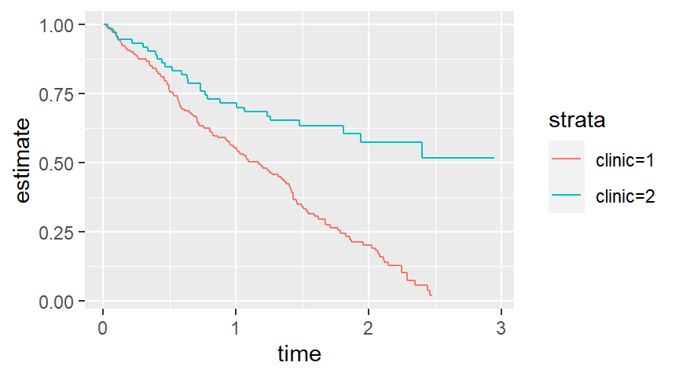

```r
heroin                                      %$%
  Surv(time_yrs, status==1)                     -> heroin_surv

heroin                                      %$%
  survfit(heroin_surv~clinic)               %>%
  tidy                                      -> km_clinic

km_clinic                                   %>%
  ggplot(aes(time, estimate, color=strata))  +
    geom_step()
```

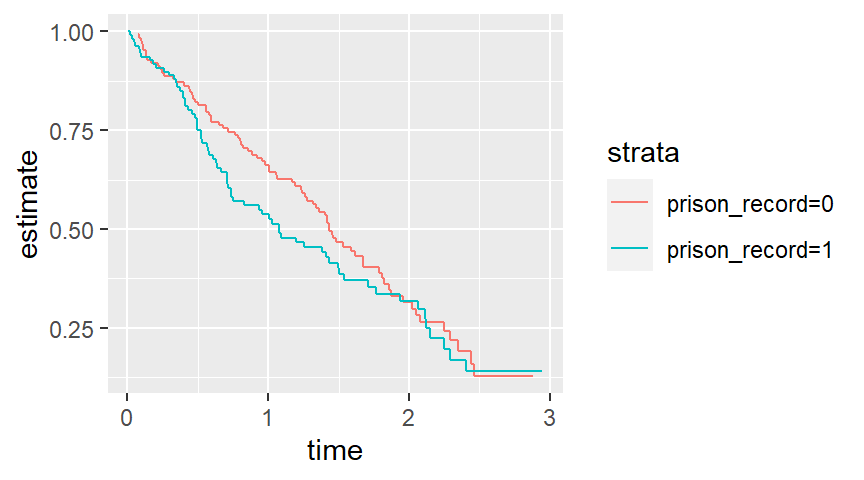

```r
heroin                                      %$%
  survfit(heroin_surv~prison_record)        %>%
  tidy                                      -> km_prison

km_prison                                   %>%
  ggplot(aes(time, estimate, color=strata))  +
    geom_step()
```

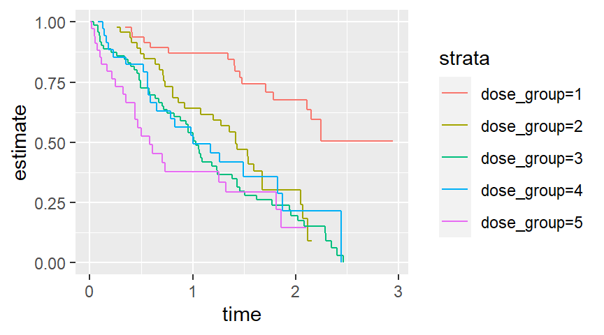

```r
heroin                                      %$%
  survfit(heroin_surv~dose_group)           %>%
  tidy                                      -> km_dose

km_dose                                     %>%
  ggplot(aes(time, estimate, color=strata))  +
    geom_step()
```

## Complementary log-log plot

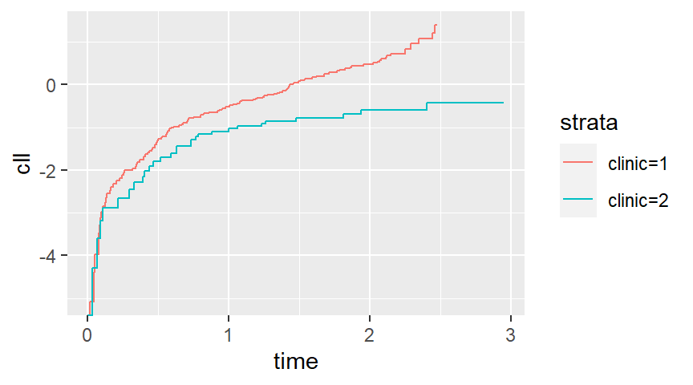

```r
km_clinic                             %>%
  mutate(cll=log(-log(estimate)))     %>%
  ggplot(aes(time, cll, color=strata)) +
    expand_limits(y=0)                 +
    geom_step()
```

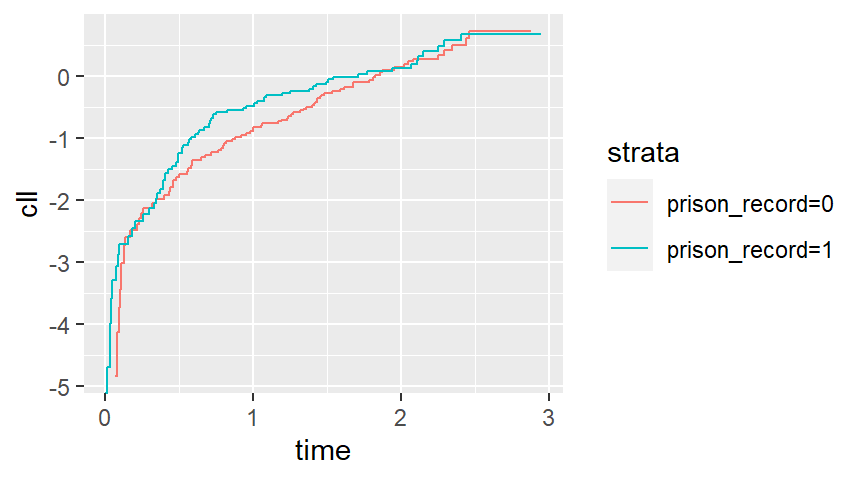

```r
km_prison                             %>%
  mutate(cll=log(-log(estimate)))     %>%
  ggplot(aes(time, cll, color=strata)) +
    expand_limits(y=0)                 +
    geom_step()
```

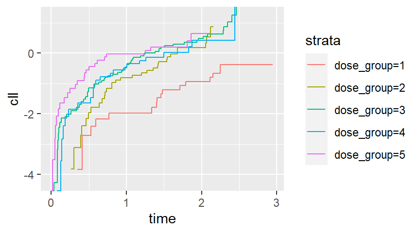

```r
km_dose                               %>%
  mutate(cll=log(-log(estimate)))     %>%
  ggplot(aes(time, cll, color=strata)) +
    expand_limits(y=0)                 +
    geom_step()
```

## Schoenfeld residuals.

```r
par(mar=c(2.6, 4.1, 0.6, 0.6))
cox_mv <- coxph(
  heroin_surv~clinic+prison_record+dose,
  data=heroin)
cox_schoenfeld <- cox.zph(cox_mv)
print(cox_schoenfeld)
```

```
##                chisq df       p
## clinic        11.159  1 0.00084
## prison_record  0.839  1 0.35969
## dose           0.515  1 0.47310
## GLOBAL        12.287  3 0.00646
```

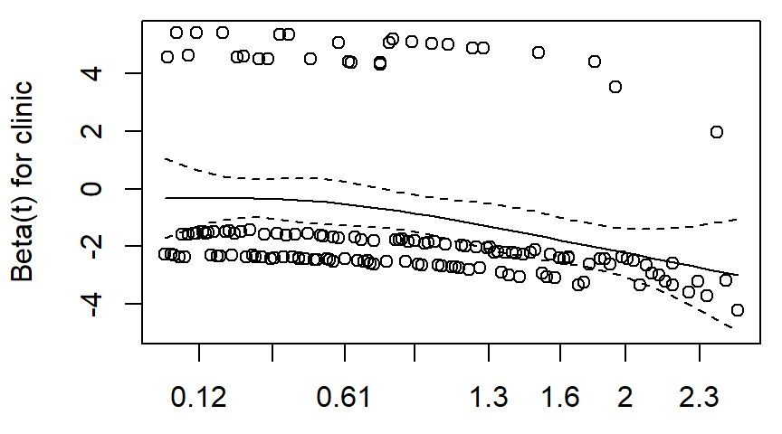

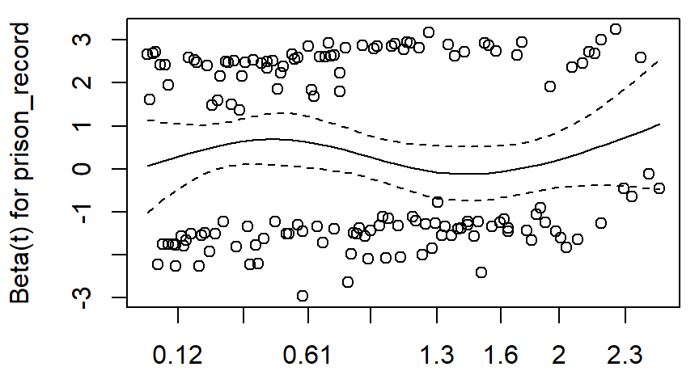

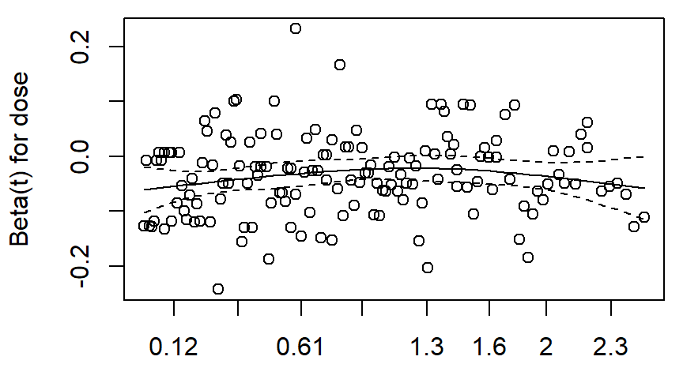

```r
plot(cox_schoenfeld)
```

## Stratified analysis

If one of the variables in your model is a nuisance variable, but it could possibly be the cause of the violation of the proportional hazards assumption, you can fit fix this by fitting a separate baseline hazard for each level of your nuisance variable.

```r
par(mar=c(2.6, 2.6, 0.6, 0.6))
cox_strata <- coxph(
  heroin_surv ~
    prison_record +
    dose +
  strata(clinic),
  data=heroin)
print(cox_strata)
```

```
## Call:
## coxph(formula = heroin_surv ~ prison_record + dose + strata(clinic),
##     data = heroin)
##
##                    coef exp(coef)  se(coef)      z        p
## prison_record  0.389605  1.476397  0.168930  2.306   0.0211
## dose          -0.035115  0.965495  0.006465 -5.432 5.59e-08
##
## Likelihood ratio test=33.91  on 2 df, p=4.322e-08
## n= 238, number of events= 150
```

```r
summary(cox_strata)
```

```
## Call:
## coxph(formula = heroin_surv ~ prison_record + dose + strata(clinic),
##     data = heroin)
##
##   n= 238, number of events= 150
##
##                    coef exp(coef)  se(coef)      z Pr(>|z|)
## prison_record  0.389605  1.476397  0.168930  2.306   0.0211 *
## dose          -0.035115  0.965495  0.006465 -5.432 5.59e-08 ***
## ---
## Signif. codes:  0 '***' 0.001 '**' 0.01 '*' 0.05 '.' 0.1 ' ' 1
##
##               exp(coef) exp(-coef) lower .95 upper .95
## prison_record    1.4764     0.6773    1.0603    2.0559
## dose             0.9655     1.0357    0.9533    0.9778
##
## Concordance= 0.651  (se = 0.026 )
## Likelihood ratio test= 33.91  on 2 df,   p=4e-08
## Wald test            = 32.66  on 2 df,   p=8e-08
## Score (logrank) test = 33.33  on 2 df,   p=6e-08
```

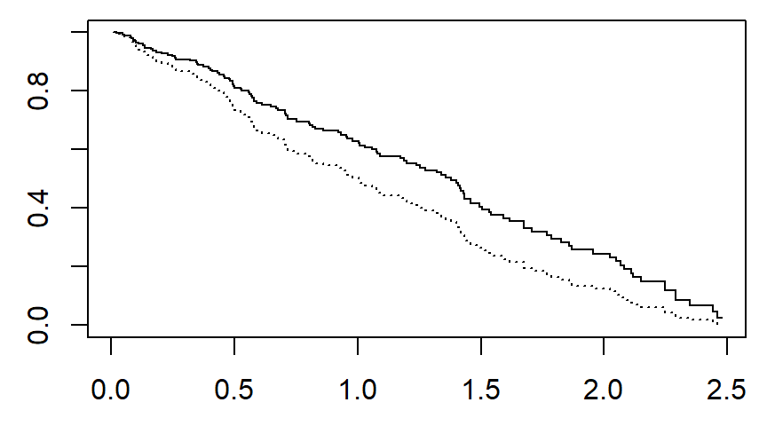

```r
n <- data.frame(
  dose=mean(heroin$dose),
  clinic=c(1, 1, 2, 2),
  prison_record=c(0, 1, 0, 1))

cox_predict <- survfit(cox_strata, newdata=n)
plot(
  cox_predict$time[1:147],
  cox_predict$surv[1:147],
  type="s", ylim=c(0,1))
lines(
  cox_predict$time[148:294],
  cox_predict$surv[148:294],
  type="s", lty="dotted")
```

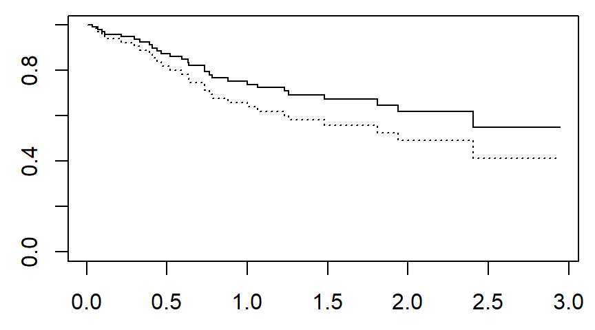

```r
plot(
  cox_predict$time[295:362],
  cox_predict$surv[295:362],
  type="s", ylim=c(0,1))
lines(
  cox_predict$time[363:430],
  cox_predict$surv[363:430],
  type="s", lty="dotted")
```

## Time-varying covariates

```r
par(mar=c(2.6, 2.6, 0.6, 0.6))
heroin$clinic <- heroin$clinic - 1
tt_clinic <- coxph(
  heroin_surv~
    clinic +
    tt(clinic) +
    prison_record +
    dose,
  tt=function(x, t, ...) x*t,
  data=heroin)
tt_clinic
```

```
## Call:
## coxph(formula = heroin_surv ~ clinic + tt(clinic) + prison_record +
##     dose, data = heroin, tt = function(x, t, ...) x * t)
##
##                    coef exp(coef)  se(coef)      z        p
## clinic         0.019395  1.019584  0.347170  0.056   0.9554
## tt(clinic)    -1.103309  0.331771  0.345281 -3.195   0.0014
## prison_record  0.389966  1.476931  0.168886  2.309   0.0209
## dose          -0.035187  0.965425  0.006443 -5.462 4.72e-08
##
## Likelihood ratio test=76.13  on 4 df, p=1.15e-15
## n= 238, number of events= 150
```

```r
summary(tt_clinic)
```

```
## Call:
## coxph(formula = heroin_surv ~ clinic + tt(clinic) + prison_record +
##     dose, data = heroin, tt = function(x, t, ...) x * t)
##
##   n= 238, number of events= 150
##
##                    coef exp(coef)  se(coef)      z Pr(>|z|)
## clinic         0.019395  1.019584  0.347170  0.056   0.9554
## tt(clinic)    -1.103309  0.331771  0.345281 -3.195   0.0014 **
## prison_record  0.389966  1.476931  0.168886  2.309   0.0209 *
## dose          -0.035187  0.965425  0.006443 -5.462 4.72e-08 ***
## ---
## Signif. codes:  0 '***' 0.001 '**' 0.01 '*' 0.05 '.' 0.1 ' ' 1
##
##               exp(coef) exp(-coef) lower .95 upper .95
## clinic           1.0196     0.9808    0.5163    2.0134
## tt(clinic)       0.3318     3.0141    0.1686    0.6527
## prison_record    1.4769     0.6771    1.0607    2.0564
## dose             0.9654     1.0358    0.9533    0.9777
##
## Concordance= 0.682  (se = 0.023 )
## Likelihood ratio test= 76.13  on 4 df,   p=1e-15
## Wald test            = 57.76  on 4 df,   p=9e-12
## Score (logrank) test = 67.09  on 4 df,   p=9e-14
```

```r
tt_coef <- tidy(tt_clinic)
beta_clinic <- unlist(tt_coef[tt_coef$term=="clinic", "estimate"])
beta_interaction <- unlist(tt_coef[tt_coef$term=="tt(clinic)", "estimate"])
t <- seq(0, 2.5, by=0.5)
log_hr <- beta_clinic+t*beta_interaction
hr <- exp(log_hr)
round(
  data.frame(
    beta_clinic,
    beta_interaction,
    t,
    log_hr,
    hr),
  3)
```

```
##   beta_clinic beta_interaction   t log_hr    hr
## 1       0.019           -1.103 0.0  0.019 1.020
## 2       0.019           -1.103 0.5 -0.532 0.587
## 3       0.019           -1.103 1.0 -1.084 0.338
## 4       0.019           -1.103 1.5 -1.636 0.195
## 5       0.019           -1.103 2.0 -2.187 0.112
## 6       0.019           -1.103 2.5 -2.739 0.065
```

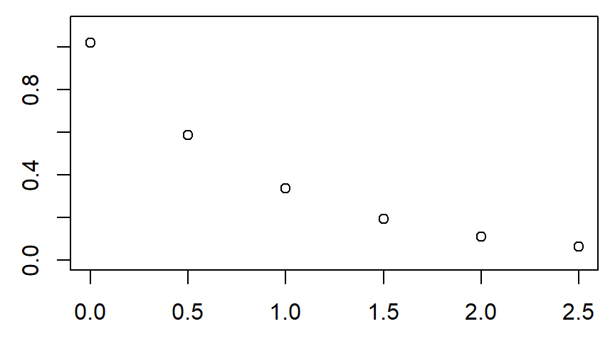

```r
plot(t, hr, ylim=c(0, 1.1))
```

## Stanford Heart Transplant study

The Stanford Heart Transplant study has an interesting application of time-varying covariates.

```r
par(mar=c(2.6, 2.6, 0.6, 0.6), las=1)
ids <- 21:30
vlist <- c(
  "accept.dt",
  "tx.date",
  "fu.date",
  "fustat",
  "transplant"
)
jasa [ids, vlist]
```

```
##     accept.dt    tx.date    fu.date fustat transplant
## 21 1969-02-01 1969-02-08 1971-11-29      1          1
## 22 1969-03-18 1969-03-29 1969-05-07      1          1
## 23 1969-04-11 1969-04-13 1971-04-13      1          1
## 24 1969-04-25 1969-07-16 1969-11-29      1          1
## 25 1969-04-28 1969-05-22 1974-04-01      0          1
## 26 1969-05-01       <NA> 1973-03-01      0          0
## 27 1969-05-04       <NA> 1970-01-21      1          0
## 28 1969-06-07 1969-08-16 1969-08-17      1          1
## 29 1969-07-14       <NA> 1969-08-17      1          0
## 30 1969-08-19 1969-09-03 1971-12-18      1          1
```

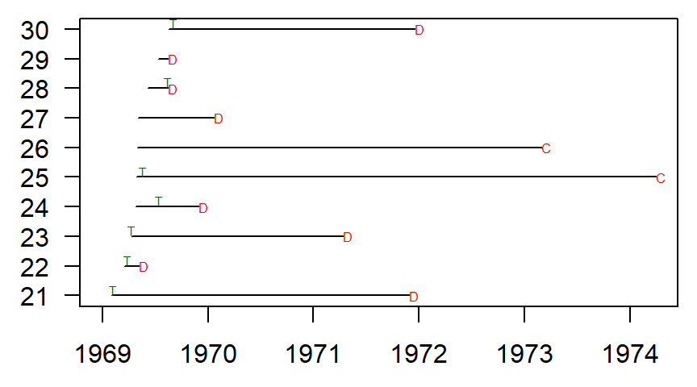

```r
t0 <- as.Date("1969-01-01")
t1 <- jasa$accept.dt[ids] - t0
t2 <- jasa$tx.date[ids] - t0
t3 <- jasa$fu.date[ids] - t0
censor <- ifelse(jasa$fustat[ids]==1, "D", "C")
plot(c(0, max(t3)), c(1,10), type="n", axes=FALSE)
axis(side=1, at=(0:5)*365.25, labels=1969:1974)
axis(side=2, at=1:10, label=ids)
box()
segments(t1, 1:10, t3, 1:10)
text(t2, (1:10)+0.2, "T", col="darkgreen", cex=0.5)
text(t3, 1:10, censor, col="red", adj=0, cex=0.5)
```

```r
data.frame(
  id=ids,
  time1=t2-t1,
  time2=t3-t1,
  event=censor,
  transplant=jasa$transplant[ids])
```

```
##    id   time1     time2 event transplant
## 1  21  7 days 1031 days     D          1
## 2  22 11 days   50 days     D          1
## 3  23  2 days  732 days     D          1
## 4  24 82 days  218 days     D          1
## 5  25 24 days 1799 days     C          1
## 6  26 NA days 1400 days     C          0
## 7  27 NA days  262 days     D          0
## 8  28 70 days   71 days     D          1
## 9  29 NA days   34 days     D          0
## 10 30 15 days  851 days     D          1
```

```r
jasax <- jasa1
row.names(jasax) <- NULL
col.names <- c("id", "start", "stop", "event", "transplant")
jasax[jasax$id %in% ids, col.names]
```

```
##    id start stop event transplant
## 30 21     0    7     0          0
## 31 21     7 1031     1          1
## 32 22     0   11     0          0
## 33 22    11   50     1          1
## 34 23     0    2     0          0
## 35 23     2  732     1          1
## 36 24     0   82     0          0
## 37 24    82  218     1          1
## 38 25     0   24     0          0
## 39 25    24 1799     0          1
## 40 26     0 1400     0          0
## 41 27     0  262     1          0
## 42 28     0   70     0          0
## 43 28    70   71     1          1
## 44 29     0   34     1          0
## 45 30     0   15     0          0
## 46 30    15  851     1          1
```

```r
cox_naive <- coxph(
  Surv(futime, fustat) ~ transplant + age + surgery,
    data=jasa)

print(cox_naive)
```

```
## Call:
## coxph(formula = Surv(futime, fustat) ~ transplant + age + surgery,
##     data = jasa)
##
##                coef exp(coef) se(coef)      z        p
## transplant -1.71711   0.17958  0.27853 -6.165 7.05e-10
## age         0.05889   1.06065  0.01505  3.913 9.12e-05
## surgery    -0.41902   0.65769  0.37118 -1.129    0.259
##
## Likelihood ratio test=45.85  on 3 df, p=6.106e-10
## n= 103, number of events= 75
```

```r
cox_time_varying <- coxph(
  Surv(start, stop, event, type="counting") ~
    transplant+age+surgery,
  data=jasa1)

print(cox_time_varying)
```

```
## Call:
## coxph(formula = Surv(start, stop, event, type = "counting") ~
##     transplant + age + surgery, data = jasa1)
##
##                coef exp(coef) se(coef)      z      p
## transplant  0.01405   1.01415  0.30822  0.046 0.9636
## age         0.03055   1.03103  0.01389  2.199 0.0279
## surgery    -0.77326   0.46150  0.35966 -2.150 0.0316
##
## Likelihood ratio test=10.72  on 3 df, p=0.01335
## n= 170, number of events= 75
```

Page 221 of Hosmer, Lemeshow, and May describes the grace data set, which you can use for time-varying covariates.

```r
fn <- "~/survival-models/data/wiley/GRACE1000.dat"
grace <- read.table(fn, header = FALSE)
names(grace) <- c(
  "id",
  "days",
  "death",
  "revasc",
  "revascdays",
  "los",
  "age",
  "sysbp",
  "stchange")
head(grace)
```

[output not shown]

```r
whas500 %$% Surv(time_yrs, fstat=="Dead") -> whas500_surv
bmi_cuts <- c(0, 25, 30, 35, 99)
whas500                                     %>%
  mutate(bmi_categories=cut(bmi, bmi_cuts)) %$%
  survfit(whas500_surv~bmi_categories)      %>%
  tidy                                      -> km_bmi
km_bmi                                      %>%
  ggplot(aes(time, estimate, color=strata))  +
    geom_step()

age_cuts <- c(0, 60, 70, 80, 999)
whas500                                     %>%
  mutate(age_categories=cut(age, age_cuts)) %$%
  survfit(whas500_surv~age_categories)      %>%
  tidy                                      -> km_age
km_age                                      %>%
  ggplot(aes(time, estimate, color=strata))  +
    geom_step()

hr_cuts <- c(0, 70, 85, 100, 999)
whas500                                    %>%
  mutate(hr_categories=cut(hr, hr_cuts))   %$%
  survfit(whas500_surv~hr_categories)      %>%
  tidy                                      -> km_hr
km_hr                                       %>%
  ggplot(aes(time, estimate, color=strata))  +
    geom_step()

diasbp_cuts <- c(0, 60, 70, 80, 999)
whas500                                     %>%
  mutate(
    diasbp_categories=
      cut(diasbp, diasbp_cuts))             %$%
  survfit(whas500_surv~diasbp_categories)   %>%
  tidy                                      -> km_diasbp
km_diasbp                                   %>%
  ggplot(aes(time, estimate, color=strata))  +
    geom_step()

whas500                                     %$%
  survfit(whas500_surv~gender)              %>%
  tidy                                      -> km_gender
km_gender                                   %>%
  ggplot(aes(time, estimate, color=strata))  +
    geom_step()

whas500                                     %$%
  survfit(whas500_surv~chf)                 %>%
  tidy                                      -> km_chf
km_chf                                      %>%
  ggplot(aes(time, estimate, color=strata))  +
    geom_step()
km_bmi                                %>%
  mutate(cll=log(-log(estimate)))     %>%
  ggplot(aes(time, cll, color=strata)) +
    geom_step()

km_age                                %>%
  mutate(cll=log(-log(estimate)))     %>%
  ggplot(aes(time, cll, color=strata)) +
    geom_step()

km_hr                                 %>%
  mutate(cll=log(-log(estimate)))     %>%
  ggplot(aes(time, cll, color=strata)) +
    geom_step()

km_diasbp                             %>%
  mutate(cll=log(-log(estimate)))     %>%
  ggplot(aes(time, cll, color=strata)) +
    geom_step()

km_gender                             %>%
  mutate(cll=log(-log(estimate)))     %>%
  ggplot(aes(time, cll, color=strata)) +
    geom_step()

km_chf                                %>%
  mutate(cll=log(-log(estimate)))     %>%
  ggplot(aes(time, cll, color=strata)) +
    geom_step()
cox_mv <- coxph(
  Surv(time_yrs, fstat=="Dead") ~
    bmi +
    age +
    gender,
  data=whas500)
cox_schoenfeld <- cox.zph(cox_mv)
print(cox_schoenfeld)
plot(cox_schoenfeld)
```

[output not shown]

Read in the leader data set.

```r
fn <- "../data/leader.txt"
leader <- read.delim(fn, sep=" ", na.strings=".")
str(leader)
```

```
## 'data.frame':    472 obs. of  13 variables:
##  $ years   : int  3 8 3 1 1 0 1 15 13 7 ...
##  $ lost    : int  2 0 3 3 3 3 3 0 2 0 ...
##  $ manner  : int  1 0 0 0 1 1 1 1 0 0 ...
##  $ start   : int  975 979 960 964 965 967 968 972 966 980 ...
##  $ military: int  0 0 0 0 1 1 0 1 0 0 ...
##  $ age     : int  53 37 44 51 56 37 50 39 45 55 ...
##  $ conflict: int  1 1 1 1 1 1 1 1 0 0 ...
##  $ loginc  : num  5.8 5.8 4.7 4.7 4.7 ...
##  $ growth  : num  -5.7 -5.7 1 1 1 1 1 1 8.5 8.5 ...
##  $ pop     : num  8 8 4 4 4 4 4 4 1.2 1.2 ...
##  $ land    : num  1247 1247 112 112 112 ...
##  $ literacy: int  20 20 11 11 11 11 11 11 30 30 ...
##  $ region  : int  1 1 1 1 1 1 1 1 1 1 ...
```

```r
leader <- leader[is.finite(leader$age), ]
lb <- c(
  "still in power",
  "constitutional exit",
  "natural death",
  "nonconstitutional exit"
)
leader$lost <- factor(leader$lost, levels=0:3, labels=lb)
lb <- c(
  "constitutional ascent",
  "nonconstitutional ascent")
leader$manner <- factor(leader$manner, levels=0:1, labels=lb)
```

Calculate some simple descriptive statistics.

```r
summary(leader$years)
```

```
##    Min. 1st Qu.  Median    Mean 3rd Qu.    Max.
##   0.000   1.000   3.000   5.114   7.000  27.000
```

```r
table(leader$lost)
```

```
##
##         still in power    constitutional exit          natural death
##                    111                    146                     27
## nonconstitutional exit
##                    154
```

```r
table(leader$manner)
```

```
##
##    constitutional ascent nonconstitutional ascent
##                      280                      158
```

```r
summary(leader$start)
```

```
##    Min. 1st Qu.  Median    Mean 3rd Qu.    Max.
##   960.0   965.0   973.0   972.6   979.0   987.0
```

```r
table(leader$military)
```

```
##
##   0   1
## 294 144
```

```r
summary(leader$age)
```

```
##    Min. 1st Qu.  Median    Mean 3rd Qu.    Max.
##   17.00   41.00   50.00   49.39   56.75   81.00
```

```r
table(leader$conflict)
```

```
##
##   0   1
## 166 272
```

```r
summary(leader$loginc)
```

```
##    Min. 1st Qu.  Median    Mean 3rd Qu.    Max.
##   4.094   5.075   5.858   5.916   6.565   9.546
```

```r
summary(leader$growth)
```

```
##    Min. 1st Qu.  Median    Mean 3rd Qu.    Max.
##   -7.00    0.50    1.50    1.63    3.40    8.50
```

```r
summary(leader$pop)
```

```
##     Min.  1st Qu.   Median     Mean  3rd Qu.     Max.
##    0.008    2.600    7.000   35.780   24.000 1088.000
```

```r
summary(leader$land)
```

```
##    Min. 1st Qu.  Median    Mean 3rd Qu.    Max.
##    0.02   49.00  238.00  739.97  912.00 9596.00
```

```r
summary(leader$literacy)
```

```
##    Min. 1st Qu.  Median    Mean 3rd Qu.    Max.
##    5.00   32.00   65.00   59.41   85.00   99.00
```

```r
table(leader$region)
```

```
##
##   0   1   2   3
##  60 132  91 155
```

First, let’s look at this model in a binary fashion, with lost = “still in power” as censored observations and “constitutional exit” and “natural death” and “non-constitutional exit” as events.

```r
leader$event <-
  (leader$lost=="constitutional exit") +
  (leader$lost=="natural death") +
  (leader$lost=="nonconstitutional exit")

table(leader$lost, leader$event, useNA="ifany")
```

```
##
##                            0   1
##   still in power         111   0
##   constitutional exit      0 146
##   natural death            0  27
##   nonconstitutional exit   0 154
```

Always check your counts to make sure you have enough events in each group.

```r
table(leader$manner, leader$event)
```

```
##
##                              0   1
##   constitutional ascent     70 210
##   nonconstitutional ascent  41 117
```

```r
table(leader$military, leader$event)
```

```
##
##       0   1
##   0  70 224
##   1  41 103
```

```r
table(leader$conflict, leader$event)
```

```
##
##       0   1
##   0  42 124
##   1  69 203
```

```r
table(leader$region, leader$event)
```

```
##
##       0   1
##   0  18  42
##   1  42  90
##   2  26  65
##   3  25 130
```

Create cut-points for continuous outcomes.

```r
leader$start_c <-
  cut(
    leader$start,
    c(1959, 1969, 1979, 1987),
    c("60s", "70s","80s"  )
)
table(leader$start_c)
```

```
##
## 60s 70s 80s
##   0   0   0
```

```r
leader$age_c <-
  cut(
    leader$age,
    c(0, 39, 59, 89),
    c("0-39", "40-59", "60+")
)
table(leader$age_c)
```

```
##
##  0-39 40-59   60+
##    89   265    84
```

```r
leader$loginc_c <-
  cut(
    leader$loginc,
    c(log(c(1, 200, 500, 100000))),
    c("$0-200", "$200-500", "$500+")
)
table(leader$loginc_c)
```

```
##
##   $0-200 $200-500    $500+
##      130      149      159
```

```r
leader$growth_c <-
  cut(
    leader$growth,
    c(-10, 0, 3.9, 10),
    c("neg", "0-3.9%", "4%+")
)
table(leader$growth_c)
```

```
##
##    neg 0-3.9%    4%+
##     85    275     78
```

```r
leader$pop_c <-
  cut(
    leader$pop,
    c(0, 1, 10, 10000),
    c("under 1m", "1-10m", "10m+")
)
table(leader$pop_c)
```

```
##
## under 1m    1-10m     10m+
##       70      189      179
```

```r
leader$land_c <-
  cut(
    leader$land,
    c(0, 100, 1000, 10000),
    c(
      "under 100 sq km",
      "100-1,000 sq km",
      "1,000-10,000 sq km")
)
table(leader$land_c)
```

```
##
##    under 100 sq km    100-1,000 sq km 1,000-10,000 sq km
##                142                198                 98
```

```r
leader$literacy_c <-
  cut(
    leader$literacy,
    c(0, 50, 75, 100),
    c("0-50%", "50-75%", "75-100%")
)
table(leader$literacy_c)
```

```
##
##   0-50%  50-75% 75-100%
##     163     103     172
```

Take a look at the calculations involved.

```r
leader_tally <- table(leader$years, leader$lost)
leader_tally
```

```
##
##      still in power constitutional exit natural death nonconstitutional exit
##   0               7                  34             2                     45
##   1              10                  15             1                     20
##   2               9                  15             2                     20
##   3               8                  17             4                     12
##   4               5                  24             2                      9
##   5               8                  17             1                     11
##   6               7                   8             2                      6
##   7               7                   0             2                      4
##   8               8                   4             0                      5
##   9               6                   0             1                      2
##   10              5                   2             0                      4
##   11              0                   2             1                      6
##   12              5                   1             3                      0
##   13              1                   0             1                      3
##   14              2                   1             2                      1
##   15              4                   0             0                      2
##   16              2                   0             0                      1
##   17              2                   2             1                      1
##   18              2                   0             1                      1
##   19              2                   0             1                      1
##   20              3                   2             0                      0
##   21              1                   0             0                      0
##   22              2                   1             0                      0
##   23              2                   0             0                      0
##   24              1                   1             0                      0
##   26              1                   0             0                      0
##   27              1                   0             0                      0
```

```r
fn <- "../data/leader_tally.csv"
write.csv(leader_tally, file=fn, row.names=FALSE)
```

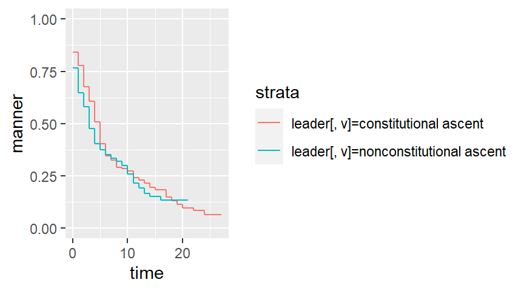

```r
binary_surv <- Surv(leader$years, leader$event)

draw_km <- function(v) {
  survfit(binary_surv~leader[ , v], data=leader)   %>%
    tidy                                           %>%
    ggplot(aes(time, estimate, color=strata))  +
      ylab(v)                                       +
      expand_limits(y=0:1)                          +
      geom_step()                                  %>%
  return
}

draw_km("manner")
```

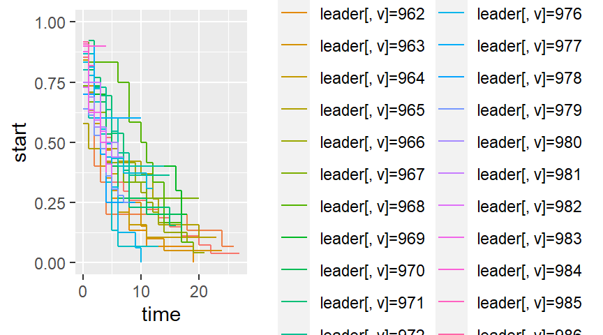

```r
draw_km("start")
```

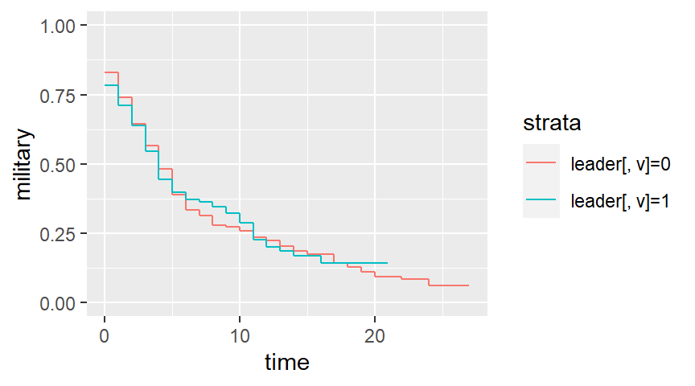

```r
draw_km("military")
```

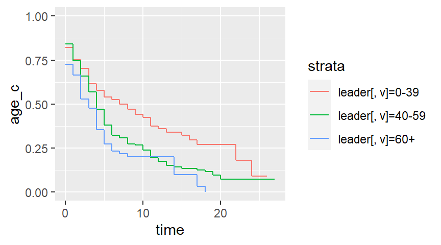

```r
draw_km("age_c")
```

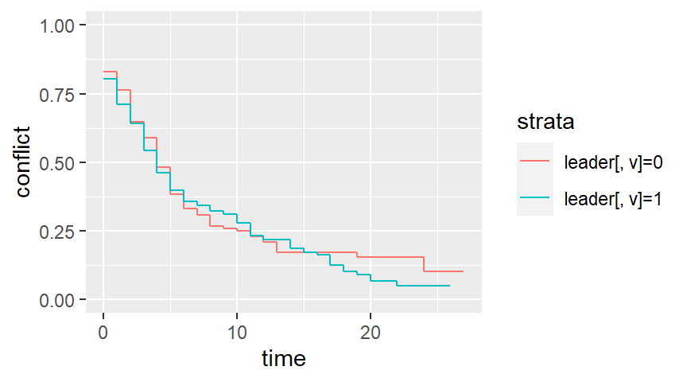

```r
draw_km("conflict")
```

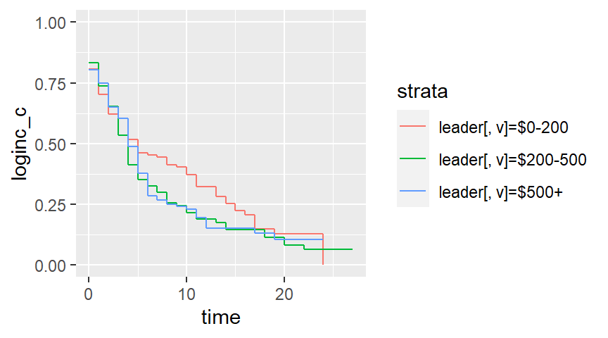

```r
draw_km("loginc_c")
```

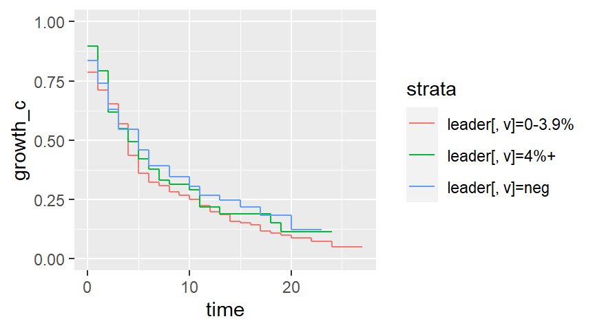

```r
draw_km("growth_c")
```

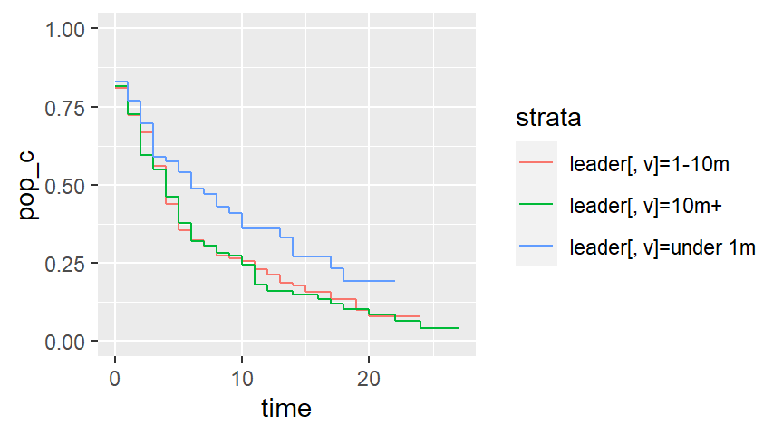

```r
draw_km("pop_c")
```

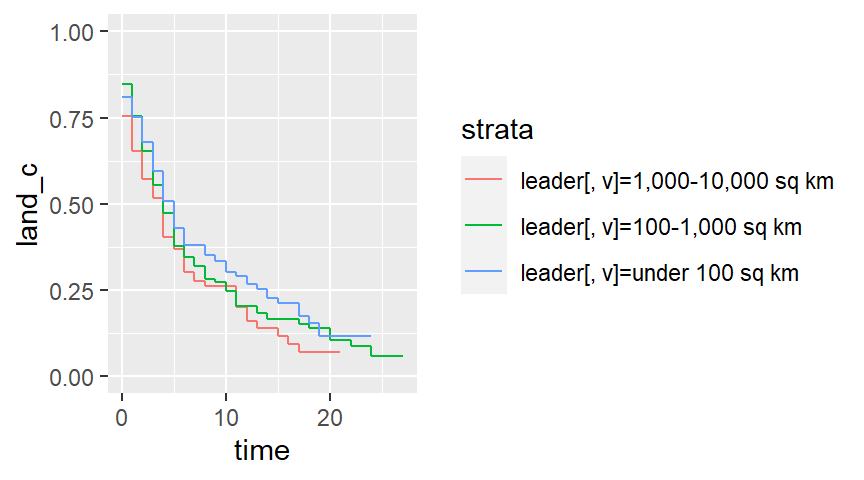

```r
draw_km("land_c")
```

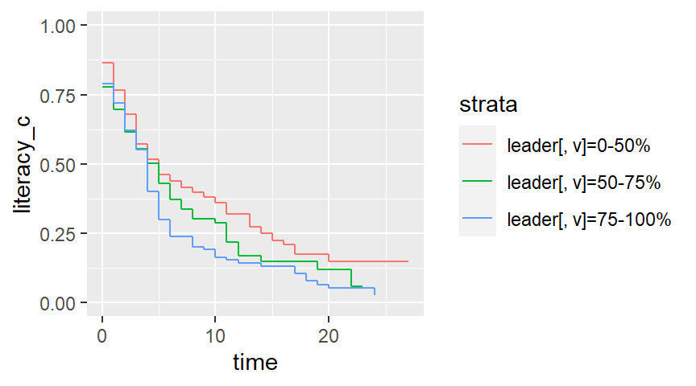

```r
draw_km("literacy_c")
```

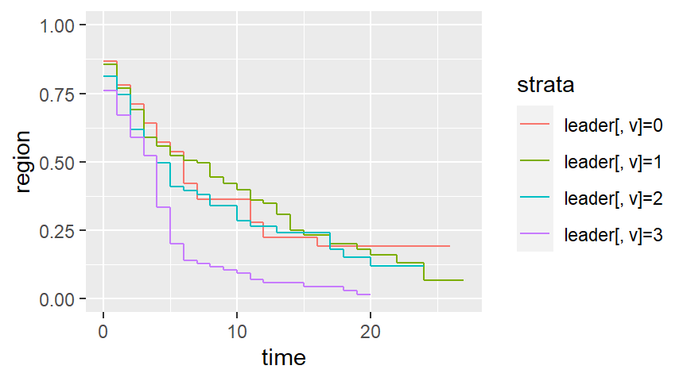

```r
draw_km("region")
```

Fit univariate Cox models

```r
coxph(binary_surv~manner, data=leader)
```

```
## Call:
## coxph(formula = binary_surv ~ manner, data = leader)
##
##                                  coef exp(coef) se(coef)     z     p
## mannernonconstitutional ascent 0.1378    1.1477   0.1158 1.189 0.234
##
## Likelihood ratio test=1.4  on 1 df, p=0.2375
## n= 438, number of events= 327
```

```r
coxph(binary_surv~start, data=leader)
```

```
## Call:
## coxph(formula = binary_surv ~ start, data = leader)
##
##            coef exp(coef)  se(coef)      z     p
## start -0.008479  0.991557  0.007808 -1.086 0.278
##
## Likelihood ratio test=1.18  on 1 df, p=0.2771
## n= 438, number of events= 327
```

```r
coxph(binary_surv~military, data=leader)
```

```
## Call:
## coxph(formula = binary_surv ~ military, data = leader)
##
##               coef exp(coef)  se(coef)      z     p
## military -0.008274  0.991760  0.119486 -0.069 0.945
##
## Likelihood ratio test=0  on 1 df, p=0.9448
## n= 438, number of events= 327
```

```r
coxph(binary_surv~age, data=leader)
```

```
## Call:
## coxph(formula = binary_surv ~ age, data = leader)
##
##         coef exp(coef) se(coef)     z        p
## age 0.021702  1.021940 0.004815 4.507 6.57e-06
##
## Likelihood ratio test=20.11  on 1 df, p=7.314e-06
## n= 438, number of events= 327
```

```r
coxph(binary_surv~conflict, data=leader)
```

```
## Call:
## coxph(formula = binary_surv ~ conflict, data = leader)
##
##             coef exp(coef) se(coef)     z     p
## conflict 0.05468   1.05620  0.11422 0.479 0.632
##
## Likelihood ratio test=0.23  on 1 df, p=0.6314
## n= 438, number of events= 327
```

```r
coxph(binary_surv~loginc, data=leader)
```

```
## Call:
## coxph(formula = binary_surv ~ loginc, data = leader)
##
##            coef exp(coef) se(coef)      z     p
## loginc -0.01285   0.98723  0.04805 -0.267 0.789
##
## Likelihood ratio test=0.07  on 1 df, p=0.7887
## n= 438, number of events= 327
```

```r
coxph(binary_surv~growth, data=leader)
```

```
## Call:
## coxph(formula = binary_surv ~ growth, data = leader)
##
##             coef exp(coef)  se(coef)      z     p
## growth -0.001549  0.998452  0.018602 -0.083 0.934
##
## Likelihood ratio test=0.01  on 1 df, p=0.9337
## n= 438, number of events= 327
```

```r
coxph(binary_surv~pop, data=leader)
```

```
## Call:
## coxph(formula = binary_surv ~ pop, data = leader)
##
##          coef exp(coef)  se(coef)     z     p
## pop 0.0003870 1.0003871 0.0004419 0.876 0.381
##
## Likelihood ratio test=0.69  on 1 df, p=0.406
## n= 438, number of events= 327
```

```r
coxph(binary_surv~land, data=leader)
```

```
## Call:
## coxph(formula = binary_surv ~ land, data = leader)
##
##           coef exp(coef)  se(coef)     z      p
## land 5.952e-05 1.000e+00 3.587e-05 1.659 0.0971
##
## Likelihood ratio test=2.44  on 1 df, p=0.118
## n= 438, number of events= 327
```

```r
coxph(binary_surv~literacy, data=leader)
```

```
## Call:
## coxph(formula = binary_surv ~ literacy, data = leader)
##
##              coef exp(coef) se(coef)     z       p
## literacy 0.006217  1.006237 0.002000 3.109 0.00188
##
## Likelihood ratio test=9.88  on 1 df, p=0.001672
## n= 438, number of events= 327
```

```r
coxph(binary_surv~region, data=leader)
```

```
## Call:
## coxph(formula = binary_surv ~ region, data = leader)
##
##           coef exp(coef) se(coef)    z       p
## region 0.27096   1.31123  0.05518 4.91 9.1e-07
##
## Likelihood ratio test=24.72  on 1 df, p=6.615e-07
## n= 438, number of events= 327
```

Fit a multivariate model

```r
binary_mv <-
  coxph(
    binary_surv~
      manner +
      military +
      age,
    data=leader
  )
summary(binary_mv)
```

```
## Call:
## coxph(formula = binary_surv ~ manner + military + age, data = leader)
##
##   n= 438, number of events= 327
##
##                                     coef exp(coef)  se(coef)      z Pr(>|z|)
## mannernonconstitutional ascent  0.359963  1.433277  0.153237  2.349   0.0188
## military                       -0.128457  0.879451  0.157289 -0.817   0.4141
## age                             0.024148  1.024442  0.004967  4.862 1.16e-06
##
## mannernonconstitutional ascent *
## military
## age                            ***
## ---
## Signif. codes:  0 '***' 0.001 '**' 0.01 '*' 0.05 '.' 0.1 ' ' 1
##
##                                exp(coef) exp(-coef) lower .95 upper .95
## mannernonconstitutional ascent    1.4333     0.6977    1.0614     1.935
## military                          0.8795     1.1371    0.6461     1.197
## age                               1.0244     0.9761    1.0145     1.034
##
## Concordance= 0.59  (se = 0.019 )
## Likelihood ratio test= 26.14  on 3 df,   p=9e-06
## Wald test            = 26.66  on 3 df,   p=7e-06
## Score (logrank) test = 26.44  on 3 df,   p=8e-06
```

Compare the Martingale residuals to each independent variable already in the model to look for non-linearities.

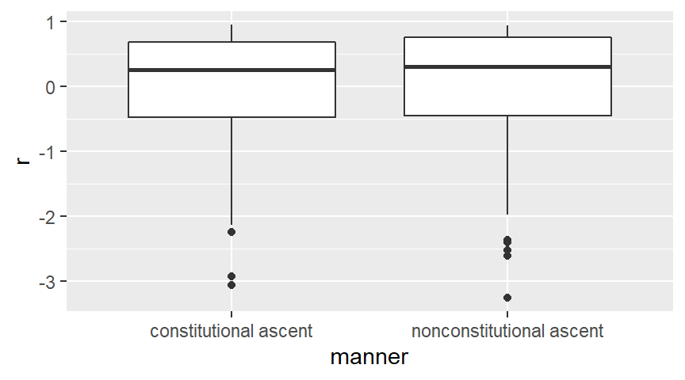

```r
leader$r <- residuals(binary_mv)
ggplot(leader, aes(manner, r))   +
  geom_boxplot()
```

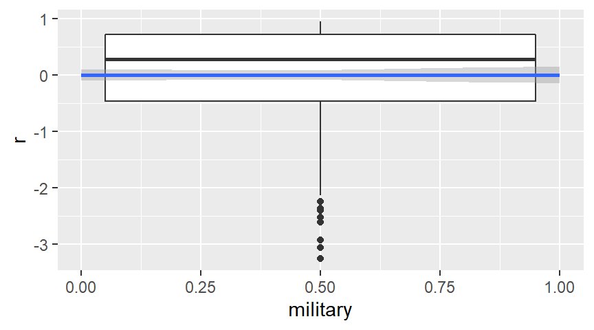

```r
ggplot(leader, aes(military, r)) +
  geom_boxplot()                 +
  geom_smooth(se=TRUE)
```

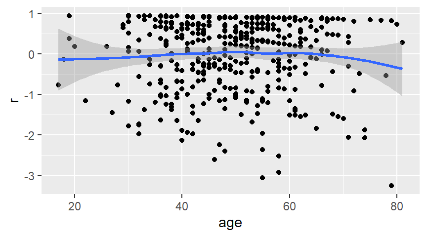

```r
ggplot(leader, aes(age, r))      +
  geom_point()                   +
  geom_smooth(se=TRUE)
```

Compare the Martingale residuals to variables not yet in the model.

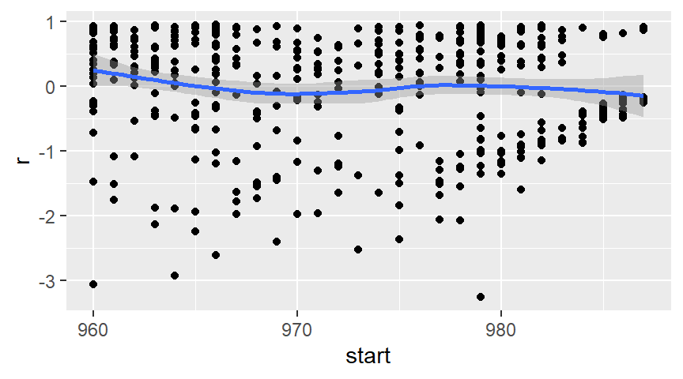

```r
leader$r <- residuals(binary_mv)
ggplot(leader, aes(start, r))    +
  geom_point()                   +
  geom_smooth(se=TRUE)
```

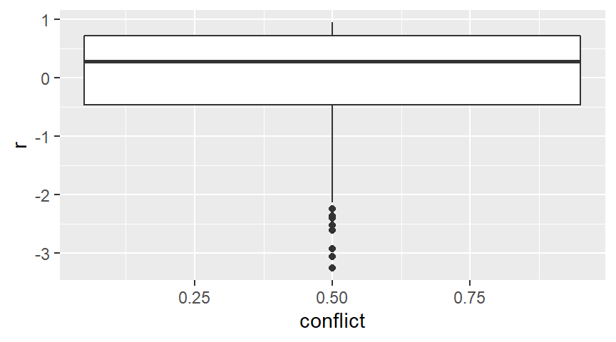

```r
ggplot(leader, aes(conflict, r)) +
  geom_boxplot()
```